# Re-analysis of Gade et al. (2021)

Author

Shaheed Azaad

# Overview

This document contains (1) a minimal reproduction of Gade et al.’s (2021; Journal of cognition) meta-analysis, and (2) a re-analysis based after fixing a critical bug in their control flow.

The main issue is this: the code contains an `if` statement that is supposed to fit models with condition random effects if each study contributes more than one effect. However, there is a bug in the code that means only models without condition random effects were fit, contrary to what is reported in the paper.

To re-run this QMD, place it inside Gade et al.’s OSF folder, found here: https://osf.io/ukjq4/

```r
library(tidyr)
library("brms")
library("ggplot2")
library("bayesplot")
temp <- read.table("Data R2/temp.txt", header=T, sep="\t") # the datafile created by the authors' processing code
options(mc.cores = 6)
set.seed(123) # the original code has no seed so numbers wont perfectly reproduce
```

# Reproducing Gade et al.’s original results

The below code fits models from Gade et al.’s script `analysis_code.R`. I only run the main analyses here (not the moderator tests).

I have made *one* modification to the code. I have added print statements to the relevant code blocks. So, if the model without random effects runs, we will see “WITHOUT CONDITION RANDOM EFFECTS” printed in the output, and if it does, we will see “WITH CONDITION RANDOM EFFECTS” printed.

## Model with interaction

```r
prior <- get_prior(
  dm ~ 1 +
    dominance +
    language_transition +
    dominance * language_transition +
    (Condition | Study),
  temp,
  family = gaussian(),
  autocor = NULL,
  sparse = NULL,
  internal = TRUE
)

if (length(temp$dm == 4 * length(unique(temp$Study)))) {
  print("WITHOUT CONDITION RANDOM EFFECTS")
  test <- brm(
    formula = dm ~ 1 +
      dominance +
      language_transition +
      dominance * language_transition +
      (1 | Study),
    data = temp,
    family = gaussian(),
    inits = 0,

    prior = c(
      set_prior("student_t(3, 847.5, 215)", class = "Intercept"),
      set_prior("normal(0,10)", class = "b"),
      set_prior("student_t(3, 0, 215)", class = "sd")
    ),
    warmup = 1000,
    iter = 5000,
    chains = 4,
    silent = 2,
    refresh = 0,
    control = list(adapt_delta = 0.95, max_treedepth = 15),
    open_progress = FALSE
  )
} else if (length(temp$dm != 4 * length(unique(temp$Study)))) {
  print("WITH CONDITION RANDOM EFFECTS")
  test <- brm(
    formula = dm ~ 1 +
      dominance +
      language_transition +
      dominance * language_transition +
      (Condition | Study),
    data = temp,
    family = gaussian(),
    inits = 0,

    prior = c(
      set_prior("student_t(3, 847.5, 215)", class = "Intercept"),
      set_prior("normal(0,10)", class = "b"),
      set_prior("student_t(3, 0, 215)", class = "sd")
    ),
    warmup = 1000,
    iter = 5000,
    chains = 4,
    silent = 2,
    refresh = 0,
    cores = 4,
    control = list(adapt_delta = 0.95, max_treedepth = 15)
  )
}
```

```
[1] "WITHOUT CONDITION RANDOM EFFECTS"
```

```r
modelwinteraction <- test

# fit criteria

modelwinteraction <- add_criterion(
  modelwinteraction,
  c("loo", "waic", "bayes_R2")
)
modelwinteraction$criteria$waic
```

```
Computed from 16000 by 956 log-likelihood matrix.

          Estimate   SE
elpd_waic  -5729.4 31.0
p_waic        65.1  4.7
waic       11458.8 62.0

38 (4.0%) p_waic estimates greater than 0.4. We recommend trying loo instead.
```

```r
modelwinteraction$criteria$loo
```

```
Computed from 16000 by 956 log-likelihood matrix.

         Estimate   SE
elpd_loo  -5730.1 31.0
p_loo        65.8  4.8
looic     11460.2 62.0
------
MCSE of elpd_loo is 0.1.
MCSE and ESS estimates assume MCMC draws (r_eff in [0.4, 2.4]).

All Pareto k estimates are good (k < 0.7).
See help('pareto-k-diagnostic') for details.
```

```r
mean(modelwinteraction$criteria$bayes_R2)
```

```
[1] 0.8105928
```

```
Using all posterior draws for ppc type 'scatter_avg' by default.
```

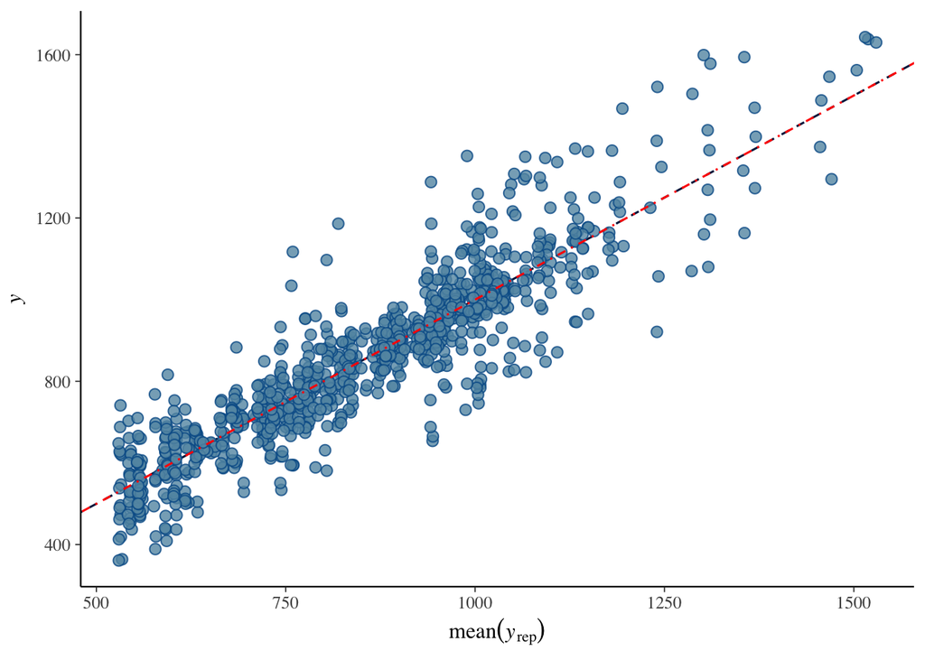

```r
#model fit
pp_check(modelwinteraction, type = "scatter_avg") +
  geom_abline(intercept = 0, slope = 1, color = "red", lty = 4) # y vs. yrep
```

## Model without interaction

```r
if (length(temp$dm == 4 * length(unique(temp$Study)))) {
  print("WITHOUT CONDITION RANDOM EFFECTS")
  test <- brm(
    formula = dm ~ 1 + dominance + language_transition + (1 | Study),
    data = temp,
    family = gaussian(),
    inits = 0,

    prior = c(
      set_prior("student_t(3, 847.5, 215)", class = "Intercept"),
      set_prior("normal(0,10)", class = "b"),
      set_prior("student_t(3, 0, 215)", class = "sd")
    ),
    warmup = 1000,
    iter = 5000,
    chains = 4,
    silent = 2,
    refresh = 0,
    control = list(adapt_delta = 0.95, max_treedepth = 15),
    open_progress = FALSE
  )
} else if (length(temp$dm != 4 * length(unique(temp$Study)))) {
  print("WITH CONDITION RANDOM EFFECTS")
  test <- brm(
    formula = dm ~ 1 + dominance + language_transition + (Condition | Study),
    data = temp,
    family = gaussian(),
    inits = 0,
    prior = c(
      set_prior("student_t(3, 847.5, 215)", class = "Intercept"),
      set_prior("normal(0,10)", class = "b"),
      set_prior("student_t(3, 0, 215)", class = "sd")
    ),
    warmup = 1000,
    iter = 5000,
    chains = 4,
    silent = 2,
    refresh = 0,
    cores = 4,
    control = list(adapt_delta = 0.95, max_treedepth = 15)
  )
}
```

```
[1] "WITHOUT CONDITION RANDOM EFFECTS"
```

```r
modelwointeraction <- test

# fit criteria

modelwointeraction <- add_criterion(
  modelwointeraction,
  c("loo", "waic", "bayes_R2")
)
modelwointeraction$criteria$waic
```

```
Computed from 16000 by 956 log-likelihood matrix.

          Estimate   SE
elpd_waic  -5729.1 31.0
p_waic        64.1  4.7
waic       11458.2 61.9

38 (4.0%) p_waic estimates greater than 0.4. We recommend trying loo instead.
```

```r
modelwointeraction$criteria$loo
```

```
Computed from 16000 by 956 log-likelihood matrix.

         Estimate   SE
elpd_loo  -5730.0 31.0
p_loo        65.0  4.8
looic     11459.9 62.0
------
MCSE of elpd_loo is 0.1.
MCSE and ESS estimates assume MCMC draws (r_eff in [0.4, 2.2]).

All Pareto k estimates are good (k < 0.7).
See help('pareto-k-diagnostic') for details.
```

```r
mean(modelwointeraction$criteria$bayes_R2)
```

```
[1] 0.8104074
```

```
Using all posterior draws for ppc type 'scatter_avg' by default.
```

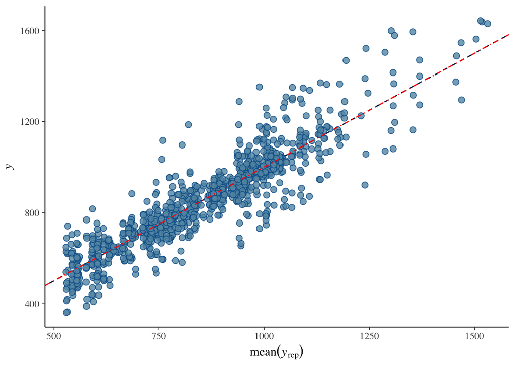

```r
#model fit
pp_check(modelwinteraction, type = "scatter_avg") +
  geom_abline(intercept = 0, slope = 1, color = "red", lty = 4) # y vs. yrep
```

### Model comparison

```r
loo(modelwinteraction, modelwointeraction)
```

```
Output of model 'modelwinteraction':

Computed from 16000 by 956 log-likelihood matrix.

         Estimate   SE
elpd_loo  -5730.1 31.0
p_loo        65.8  4.8
looic     11460.2 62.0
------
MCSE of elpd_loo is 0.1.
MCSE and ESS estimates assume MCMC draws (r_eff in [0.4, 2.4]).

All Pareto k estimates are good (k < 0.7).
See help('pareto-k-diagnostic') for details.

Output of model 'modelwointeraction':

Computed from 16000 by 956 log-likelihood matrix.

         Estimate   SE
elpd_loo  -5730.0 31.0
p_loo        65.0  4.8
looic     11459.9 62.0
------
MCSE of elpd_loo is 0.1.
MCSE and ESS estimates assume MCMC draws (r_eff in [0.4, 2.2]).

All Pareto k estimates are good (k < 0.7).
See help('pareto-k-diagnostic') for details.

Model comparisons:
                   elpd_diff se_diff
modelwointeraction  0.0       0.0
modelwinteraction  -0.2       1.1
```

### Fixed effects

```r
fixef(modelwinteraction)
```

```
                                Estimate Est.Error       Q2.5      Q97.5
Intercept                     891.182958 23.599898 844.975667 936.992358
dominance                      -4.411621  2.873638 -10.035154   1.107651
language_transition            27.008442  2.849024  21.464500  32.615405
dominance:language_transition  -3.084775  2.881656  -8.552922   2.532855
```

```r
fixef(modelwointeraction)
```

```
                      Estimate Est.Error      Q2.5      Q97.5
Intercept           891.772506 23.195907 846.05621 938.318742
dominance            -4.404365  2.943176 -10.09353   1.325606
language_transition  26.998396  2.933094  21.23849  32.677898
```

## Summary

As in the paper the model without an interaction term fit better. And the credible intervals for switch cost asymmetry and language dominance cross zero.

But as the output shows, there is a bug in the control flow. We can see that the “WITHOUT CONDITION RANDOM EFFECTS” is printed both times. In other words, the model without condition random effects was run.

The issue is in the `if` statements. The below code appears to be written to check if the length of the `dm` (RT) column equals the number of unique studies. If these don’t match, it would mean that studies contribute multiple effects.

However, a misplaced parenthesis means that what it *actually* does is compare each value of `dm` to the number of unique studies, and then returns the length of that vector. In this case, 956:

```r
length(temp$dm != 4 * length(unique(temp$Study)))
```

```
[1] 956
```

The correct version is this, which checks whether there are more RTs than studies. It evaluates to `TRUE` as we’d expect.

```r
length(temp$dm) > 4 * length(unique(temp$Study))
```

```
[1] TRUE
```

In other words, none of these models had random effects for `condition`, which meant that between-condition variability went into the residual. This is a problem not only for the models themselves, but for the paper, which states that there *were* condition random effects.

# After correccting

Here, I re-run the analyses by removing the `if` statement since we know that studies contribute multiple conditions. Note that I do not think this is the best way to analyse the data either, since effects are not weighted by their precision as they should be in a meta-analysis. This re-analysis is just to show the consequence of the bug.

The original code added random effects per condition with `(Condition|Study)` but this doesn’t match the article’s description for conditions *within* studies.

So I have changed the relevant code to match, adding the following terms: `(1 | Study) + (1 | Study:Condition)`.

## Model with interaction

```r
  test <- brm(
    formula = dm ~ 1 +
      dominance +
      language_transition +
      dominance * language_transition +
      (1 | Study) + (1 | Study:Condition),
    data = temp,
    family = gaussian(),
    inits = 0,

    prior = c(
      set_prior("student_t(3, 847.5, 215)", class = "Intercept"),
      set_prior("normal(0,10)", class = "b"),
      set_prior("student_t(3, 0, 215)", class = "sd")
    ),
    warmup = 1000,
    iter = 5000,
    chains = 4,
    silent = 2,
    refresh = 0,
    control = list(adapt_delta = 0.95, max_treedepth = 15),
    open_progress = FALSE
  )
modelwinteraction <- test

# fit criteria

modelwinteraction <- add_criterion(
  modelwinteraction,
  c("loo", "waic", "bayes_R2")
)
modelwinteraction$criteria$waic
```

```
Computed from 16000 by 956 log-likelihood matrix.

          Estimate   SE
elpd_waic  -4985.9 37.4
p_waic       208.3 14.8
waic        9971.7 74.9

116 (12.1%) p_waic estimates greater than 0.4. We recommend trying loo instead.
```

```r
modelwinteraction$criteria$loo
```

```
Computed from 16000 by 956 log-likelihood matrix.

         Estimate   SE
elpd_loo  -4996.9 37.9
p_loo       219.3 15.3
looic      9993.9 75.8
------
MCSE of elpd_loo is NA.
MCSE and ESS estimates assume MCMC draws (r_eff in [0.3, 1.1]).

Pareto k diagnostic values:
                         Count Pct.    Min. ESS
(-Inf, 0.7]   (good)     951   99.5%   266
   (0.7, 1]   (bad)        3    0.3%   <NA>
   (1, Inf)   (very bad)   2    0.2%   <NA>
See help('pareto-k-diagnostic') for details.
```

```r
mean(modelwinteraction$criteria$bayes_R2)
```

```
[1] 0.9668452
```

```
Using all posterior draws for ppc type 'scatter_avg' by default.
```

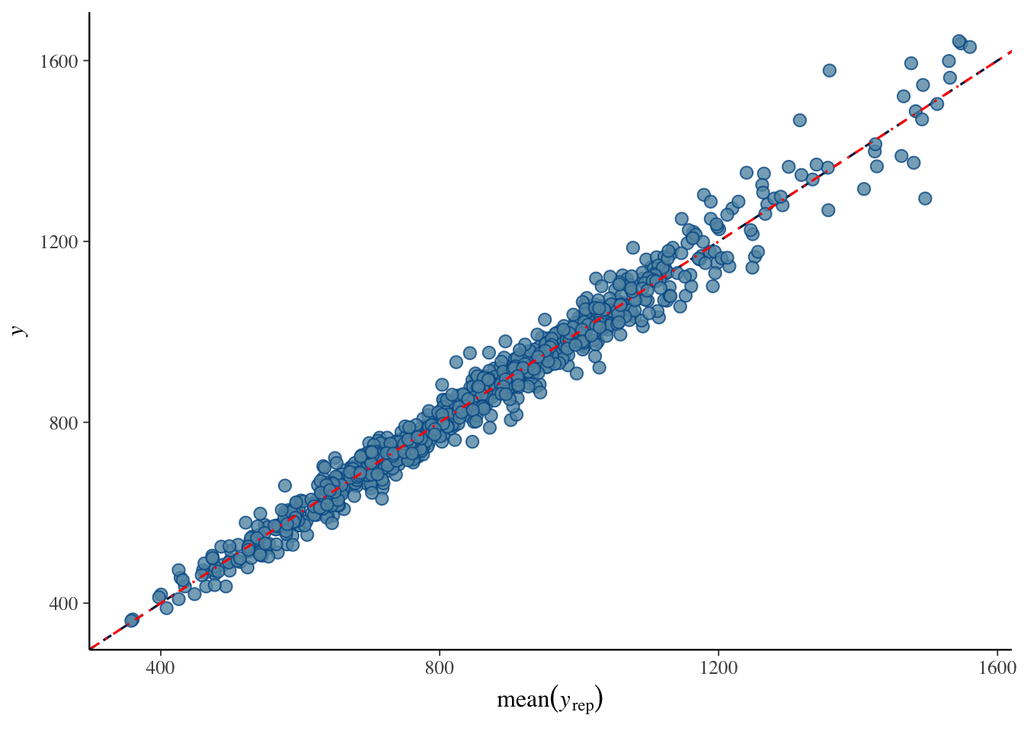

```r
#model fit
pp_check(modelwinteraction, type = "scatter_avg") +
  geom_abline(intercept = 0, slope = 1, color = "red", lty = 4) # y vs. yrep
```

## Model without interaction

```r
  test <- brm(
    formula = dm ~ 1 + dominance + language_transition +
      (1 | Study) + (1 | Study:Condition),
    data = temp,
    family = gaussian(),
    inits = 0,
    prior = c(
      set_prior("student_t(3, 847.5, 215)", class = "Intercept"),
      set_prior("normal(0,10)", class = "b"),
      set_prior("student_t(3, 0, 215)", class = "sd")
    ),
    warmup = 1000,
    iter = 5000,
    chains = 4,
    silent = 2,
    refresh = 0,
    control = list(adapt_delta = 0.95, max_treedepth = 15),
    open_progress = FALSE
  )
modelwointeraction <- test

# fit criteria

modelwointeraction <- add_criterion(
  modelwointeraction,
  c("loo", "waic", "bayes_R2")
)
modelwointeraction$criteria$waic
```

```
Computed from 16000 by 956 log-likelihood matrix.

          Estimate   SE
elpd_waic  -4989.4 37.3
p_waic       207.8 14.6
waic        9978.7 74.5

119 (12.4%) p_waic estimates greater than 0.4. We recommend trying loo instead.
```

```r
modelwointeraction$criteria$loo
```

```
Computed from 16000 by 956 log-likelihood matrix.

         Estimate   SE
elpd_loo  -5000.8 38.0
p_loo       219.2 15.3
looic     10001.6 76.0
------
MCSE of elpd_loo is NA.
MCSE and ESS estimates assume MCMC draws (r_eff in [0.3, 1.1]).

Pareto k diagnostic values:
                         Count Pct.    Min. ESS
(-Inf, 0.7]   (good)     951   99.5%   257
   (0.7, 1]   (bad)        4    0.4%   <NA>
   (1, Inf)   (very bad)   1    0.1%   <NA>
See help('pareto-k-diagnostic') for details.
```

```r
mean(modelwointeraction$criteria$bayes_R2)
```

```
[1] 0.9665754
```

```
Using all posterior draws for ppc type 'scatter_avg' by default.
```

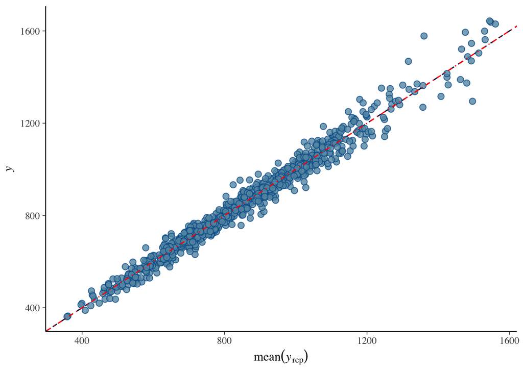

```r
#model fit
pp_check(modelwinteraction, type = "scatter_avg") +
  geom_abline(intercept = 0, slope = 1, color = "red", lty = 4) # y vs. yrep
```

### Model comparison

```r
loo(modelwinteraction, modelwointeraction)
```

```
Output of model 'modelwinteraction':

Computed from 16000 by 956 log-likelihood matrix.

         Estimate   SE
elpd_loo  -4996.9 37.9
p_loo       219.3 15.3
looic      9993.9 75.8
------
MCSE of elpd_loo is NA.
MCSE and ESS estimates assume MCMC draws (r_eff in [0.3, 1.1]).

Pareto k diagnostic values:
                         Count Pct.    Min. ESS
(-Inf, 0.7]   (good)     951   99.5%   266
   (0.7, 1]   (bad)        3    0.3%   <NA>
   (1, Inf)   (very bad)   2    0.2%   <NA>
See help('pareto-k-diagnostic') for details.

Output of model 'modelwointeraction':

Computed from 16000 by 956 log-likelihood matrix.

         Estimate   SE
elpd_loo  -5000.8 38.0
p_loo       219.2 15.3
looic     10001.6 76.0
------
MCSE of elpd_loo is NA.
MCSE and ESS estimates assume MCMC draws (r_eff in [0.3, 1.1]).

Pareto k diagnostic values:
                         Count Pct.    Min. ESS
(-Inf, 0.7]   (good)     951   99.5%   257
   (0.7, 1]   (bad)        4    0.4%   <NA>
   (1, Inf)   (very bad)   1    0.1%   <NA>
See help('pareto-k-diagnostic') for details.

Model comparisons:
                   elpd_diff se_diff
modelwinteraction   0.0       0.0
modelwointeraction -3.9       3.1
```

### Fixed effects

```r
fixef(modelwinteraction)
```

```
                                Estimate Est.Error       Q2.5       Q97.5
Intercept                     891.425594 23.625929 845.267527 937.5813229
dominance                      -4.764928  1.253318  -7.262490  -2.2704648
language_transition            28.994945  1.254326  26.560688  31.4568412
dominance:language_transition  -3.356672  1.270449  -5.840647  -0.8818071
```

```r
fixef(modelwointeraction)
```

```
                      Estimate Est.Error       Q2.5      Q97.5
Intercept           891.662980 23.791277 844.785653 939.561634
dominance            -4.775944  1.259692  -7.251892  -2.294373
language_transition  28.995219  1.280152  26.427491  31.518138
```

```r
library(emmeans)
grid <- list(dominance = c(-1, 1), language_transition = c(-1, 1))

emm <- emmeans(modelwinteraction, ~ language_transition | dominance, at = grid)
emm
```

```
dominance = -1:
 language_transition emmean lower.HPD upper.HPD
                  -1    864       819       912
                   1    928       883       976

dominance =  1:
 language_transition emmean lower.HPD upper.HPD
                  -1    861       816       909
                   1    912       867       960

Point estimate displayed: median
HPD interval probability: 0.95
```

```r
sc <- contrast(emm, method = list(switch_cost = c(-1, 1)))
sc
```

```
dominance = -1:
 contrast    estimate lower.HPD upper.HPD
 switch_cost     64.7      57.8      71.8

dominance =  1:
 contrast    estimate lower.HPD upper.HPD
 switch_cost     51.3      44.6      58.6

Point estimate displayed: median
HPD interval probability: 0.95
```

```r
contrast(sc, method = list(asymmetry = c(1, -1)), by = NULL)
```

```
 contrast  estimate lower.HPD upper.HPD
 asymmetry     13.4      3.41      23.2

Point estimate displayed: median
HPD interval probability: 0.95
```

## Summary

The fit flips: the model *with* interaction fits better now. And the relevant coefficients’ credible intervals no longer include zero. The posterior predictive checks look a lot better, too.

The coefficients are, of course, not the actual RT differences because of the -1/+1 coding. The emmeans output suggests that the asymmetry is around 13ms.